# Tourism - Copy

```python
#Loading needed Libraries
import numpy as np
import pandas as pd
import matplotlib.pyplot as plt
import seaborn as sns
from sklearn.tree import DecisionTreeClassifier
from sklearn.model_selection import train_test_split
from sklearn.metrics import confusion_matrix, classification_report
from sklearn.metrics import accuracy_score,precision_score,recall_score,f1_score
import scipy.stats as stats
from sklearn import metrics
from sklearn import tree
from sklearn.model_selection import GridSearchCV
from sklearn.ensemble import BaggingClassifier
from sklearn.ensemble import RandomForestClassifier
from sklearn.metrics import roc_auc_score
from sklearn.tree import DecisionTreeRegressor
from sklearn.ensemble import BaggingRegressor,RandomForestRegressor, GradientBoostingRegressor, AdaBoostRegressor, StackingRegressor
from xgboost import XGBRegressor
from sklearn.model_selection import train_test_split
from sklearn.ensemble import AdaBoostClassifier, GradientBoostingClassifier
from xgboost import XGBClassifier
from sklearn.ensemble import StackingClassifier
import warnings
warnings.filterwarnings('ignore')
```

```python
#Loading data set

#****IMPORTANT: THE "DATA DICT" TAB MUST BE DELETED FROM THE EXCEL TOURISM SPREAD SHEET, BEFORE IMPORTING BELOW; TO ENSURE PROPER LOADING OF FILE AND EXECUTION OF CODE.****

Tr = pd.read_csv('Tourism.csv')
```

```python
#Making a copy of the data set to preserve integrity
df=Tr.copy()
print(f'There are {df.shape[0]} rows and {df.shape[1]} columns.')  # f-string
#Viewing random rows
np.random.seed(1)
df.sample(n=10)
```

```
There are 4888 rows and 20 columns.
```

|  | CustomerID | ProdTaken | Age | TypeofContact | CityTier | DurationOfPitch | Occupation | Gender | NumberOfPersonVisiting | NumberOfFollowups | ProductPitched | PreferredPropertyStar | MaritalStatus | NumberOfTrips | Passport | PitchSatisfactionScore | OwnCar | NumberOfChildrenVisiting | Designation | MonthlyIncome |
| --- | --- | --- | --- | --- | --- | --- | --- | --- | --- | --- | --- | --- | --- | --- | --- | --- | --- | --- | --- | --- |
| 3015 | 203015 | 0 | 27.0 | Company Invited | 1 | 7.0 | Salaried | Female | 4 | 6.0 | Basic | 3.0 | Married | 5.0 | 0 | 4 | 1 | 3.0 | Executive | 23042.0 |
| 1242 | 201242 | 0 | 40.0 | Self Enquiry | 3 | 13.0 | Small Business | Male | 2 | 3.0 | King | 4.0 | Single | 2.0 | 0 | 4 | 1 | NaN | VP | 34833.0 |
| 3073 | 203073 | 0 | 29.0 | Self Enquiry | 2 | 15.0 | Small Business | Male | 4 | 5.0 | Basic | 3.0 | Married | 3.0 | 0 | 2 | 0 | 2.0 | Executive | 23614.0 |
| 804 | 200804 | 0 | 48.0 | Company Invited | 1 | 6.0 | Small Business | Male | 2 | 1.0 | Super Deluxe | 3.0 | Single | 3.0 | 0 | 2 | 0 | 0.0 | AVP | 31885.0 |
| 3339 | 203339 | 0 | 32.0 | Self Enquiry | 1 | 18.0 | Small Business | Male | 4 | 4.0 | Deluxe | 5.0 | Divorced | 3.0 | 1 | 2 | 0 | 3.0 | Manager | 25511.0 |
| 3080 | 203080 | 1 | 36.0 | Company Invited | 1 | 32.0 | Salaried | Female | 4 | 4.0 | Basic | 4.0 | Married | 3.0 | 1 | 3 | 0 | 1.0 | Executive | 20700.0 |
| 2851 | 202851 | 0 | 46.0 | Self Enquiry | 1 | 17.0 | Salaried | Male | 4 | 4.0 | Basic | 3.0 | Divorced | 5.0 | 0 | 5 | 1 | 1.0 | Executive | 21332.0 |
| 2883 | 202883 | 1 | 32.0 | Company Invited | 1 | 27.0 | Salaried | Male | 4 | 4.0 | Standard | 3.0 | Divorced | 5.0 | 0 | 3 | 1 | 1.0 | Senior Manager | 28502.0 |
| 1676 | 201676 | 0 | 22.0 | Self Enquiry | 1 | 11.0 | Salaried | Male | 2 | 1.0 | Basic | 4.0 | Married | 2.0 | 1 | 4 | 1 | 0.0 | Executive | 17328.0 |
| 1140 | 201140 | 0 | 44.0 | Self Enquiry | 1 | 13.0 | Small Business | Female | 2 | 3.0 | King | 3.0 | Married | 1.0 | 1 | 4 | 1 | 1.0 | VP | 34049.0 |

```python
#Viewing first 5 lines of the data set
df.head()
```

|  | CustomerID | ProdTaken | Age | TypeofContact | CityTier | DurationOfPitch | Occupation | Gender | NumberOfPersonVisiting | NumberOfFollowups | ProductPitched | PreferredPropertyStar | MaritalStatus | NumberOfTrips | Passport | PitchSatisfactionScore | OwnCar | NumberOfChildrenVisiting | Designation | MonthlyIncome |
| --- | --- | --- | --- | --- | --- | --- | --- | --- | --- | --- | --- | --- | --- | --- | --- | --- | --- | --- | --- | --- |
| 0 | 200000 | 1 | 41.0 | Self Enquiry | 3 | 6.0 | Salaried | Female | 3 | 3.0 | Deluxe | 3.0 | Single | 1.0 | 1 | 2 | 1 | 0.0 | Manager | 20993.0 |
| 1 | 200001 | 0 | 49.0 | Company Invited | 1 | 14.0 | Salaried | Male | 3 | 4.0 | Deluxe | 4.0 | Divorced | 2.0 | 0 | 3 | 1 | 2.0 | Manager | 20130.0 |
| 2 | 200002 | 1 | 37.0 | Self Enquiry | 1 | 8.0 | Free Lancer | Male | 3 | 4.0 | Basic | 3.0 | Single | 7.0 | 1 | 3 | 0 | 0.0 | Executive | 17090.0 |
| 3 | 200003 | 0 | 33.0 | Company Invited | 1 | 9.0 | Salaried | Female | 2 | 3.0 | Basic | 3.0 | Divorced | 2.0 | 1 | 5 | 1 | 1.0 | Executive | 17909.0 |
| 4 | 200004 | 0 | NaN | Self Enquiry | 1 | 8.0 | Small Business | Male | 2 | 3.0 | Basic | 4.0 | Divorced | 1.0 | 0 | 5 | 1 | 0.0 | Executive | 18468.0 |

```python
#Viewing last 5 lines
df.tail()
```

|  | CustomerID | ProdTaken | Age | TypeofContact | CityTier | DurationOfPitch | Occupation | Gender | NumberOfPersonVisiting | NumberOfFollowups | ProductPitched | PreferredPropertyStar | MaritalStatus | NumberOfTrips | Passport | PitchSatisfactionScore | OwnCar | NumberOfChildrenVisiting | Designation | MonthlyIncome |
| --- | --- | --- | --- | --- | --- | --- | --- | --- | --- | --- | --- | --- | --- | --- | --- | --- | --- | --- | --- | --- |
| 4883 | 204883 | 1 | 49.0 | Self Enquiry | 3 | 9.0 | Small Business | Male | 3 | 5.0 | Deluxe | 4.0 | Unmarried | 2.0 | 1 | 1 | 1 | 1.0 | Manager | 26576.0 |
| 4884 | 204884 | 1 | 28.0 | Company Invited | 1 | 31.0 | Salaried | Male | 4 | 5.0 | Basic | 3.0 | Single | 3.0 | 1 | 3 | 1 | 2.0 | Executive | 21212.0 |
| 4885 | 204885 | 1 | 52.0 | Self Enquiry | 3 | 17.0 | Salaried | Female | 4 | 4.0 | Standard | 4.0 | Married | 7.0 | 0 | 1 | 1 | 3.0 | Senior Manager | 31820.0 |
| 4886 | 204886 | 1 | 19.0 | Self Enquiry | 3 | 16.0 | Small Business | Male | 3 | 4.0 | Basic | 3.0 | Single | 3.0 | 0 | 5 | 0 | 2.0 | Executive | 20289.0 |
| 4887 | 204887 | 1 | 36.0 | Self Enquiry | 1 | 14.0 | Salaried | Male | 4 | 4.0 | Basic | 4.0 | Unmarried | 3.0 | 1 | 3 | 1 | 2.0 | Executive | 24041.0 |

```python
#Dropping CustomerID as it is redundant
df.drop(['CustomerID'],axis=1,inplace=True)
```

```python
df.sample(n=10)
```

|  | ProdTaken | Age | TypeofContact | CityTier | DurationOfPitch | Occupation | Gender | NumberOfPersonVisiting | NumberOfFollowups | ProductPitched | PreferredPropertyStar | MaritalStatus | NumberOfTrips | Passport | PitchSatisfactionScore | OwnCar | NumberOfChildrenVisiting | Designation | MonthlyIncome |
| --- | --- | --- | --- | --- | --- | --- | --- | --- | --- | --- | --- | --- | --- | --- | --- | --- | --- | --- | --- |
| 1939 | 1 | 32.0 | Company Invited | 3 | NaN | Salaried | Male | 2 | 1.0 | Deluxe | 3.0 | Married | 1.0 | 0 | 3 | 1 | 0.0 | Manager | 19707.0 |
| 4291 | 0 | 37.0 | Self Enquiry | 1 | 9.0 | Salaried | Female | 4 | 4.0 | Basic | 3.0 | Married | 6.0 | 0 | 5 | 1 | 1.0 | Executive | 21221.0 |
| 685 | 0 | 26.0 | Company Invited | 3 | NaN | Small Business | Male | 2 | 4.0 | Deluxe | 5.0 | Single | 2.0 | 0 | 3 | 1 | 1.0 | Manager | NaN |
| 2740 | 1 | 19.0 | Self Enquiry | 1 | 10.0 | Salaried | Male | 3 | 4.0 | Basic | 3.0 | Single | 3.0 | 0 | 4 | 0 | 1.0 | Executive | 20098.0 |
| 3595 | 0 | 29.0 | Self Enquiry | 1 | 34.0 | Small Business | Female | 3 | 6.0 | Deluxe | 5.0 | Married | 2.0 | 0 | 4 | 1 | 1.0 | Manager | 23886.0 |
| 3554 | 1 | 36.0 | Self Enquiry | 1 | 9.0 | Salaried | Female | 4 | 4.0 | Basic | 5.0 | Married | 3.0 | 1 | 1 | 1 | 2.0 | Executive | 20752.0 |
| 1375 | 1 | 32.0 | Company Invited | 1 | 11.0 | Salaried | Female | 2 | 1.0 | Basic | 3.0 | Single | 4.0 | 1 | 1 | 0 | 1.0 | Executive | 17432.0 |
| 2455 | 0 | 30.0 | Self Enquiry | 1 | 22.0 | Salaried | Female | 3 | 5.0 | Deluxe | 3.0 | Unmarried | 2.0 | 1 | 3 | 0 | 1.0 | Manager | 22871.0 |
| 107 | 1 | 25.0 | Self Enquiry | 3 | 11.0 | Small Business | Male | 2 | 4.0 | Deluxe | 3.0 | Single | 2.0 | 1 | 3 | 1 | 0.0 | Manager | 20744.0 |
| 423 | 0 | 30.0 | Company Invited | 3 | 28.0 | Salaried | Female | 3 | 3.0 | Standard | 5.0 | Divorced | 1.0 | 0 | 2 | 1 | 0.0 | Senior Manager | 23412.0 |

```python
#Looking for negative values
df.describe().T
```

|  | count | mean | std | min | 25% | 50% | 75% | max |
| --- | --- | --- | --- | --- | --- | --- | --- | --- |
| ProdTaken | 4888.0 | 0.188216 | 0.390925 | 0.0 | 0.0 | 0.0 | 0.0 | 1.0 |
| Age | 4662.0 | 37.622265 | 9.316387 | 18.0 | 31.0 | 36.0 | 44.0 | 61.0 |
| CityTier | 4888.0 | 1.654255 | 0.916583 | 1.0 | 1.0 | 1.0 | 3.0 | 3.0 |
| DurationOfPitch | 4637.0 | 15.490835 | 8.519643 | 5.0 | 9.0 | 13.0 | 20.0 | 127.0 |
| NumberOfPersonVisiting | 4888.0 | 2.905074 | 0.724891 | 1.0 | 2.0 | 3.0 | 3.0 | 5.0 |
| NumberOfFollowups | 4843.0 | 3.708445 | 1.002509 | 1.0 | 3.0 | 4.0 | 4.0 | 6.0 |
| PreferredPropertyStar | 4862.0 | 3.581037 | 0.798009 | 3.0 | 3.0 | 3.0 | 4.0 | 5.0 |
| NumberOfTrips | 4748.0 | 3.236521 | 1.849019 | 1.0 | 2.0 | 3.0 | 4.0 | 22.0 |
| Passport | 4888.0 | 0.290917 | 0.454232 | 0.0 | 0.0 | 0.0 | 1.0 | 1.0 |
| PitchSatisfactionScore | 4888.0 | 3.078151 | 1.365792 | 1.0 | 2.0 | 3.0 | 4.0 | 5.0 |
| OwnCar | 4888.0 | 0.620295 | 0.485363 | 0.0 | 0.0 | 1.0 | 1.0 | 1.0 |
| NumberOfChildrenVisiting | 4822.0 | 1.187267 | 0.857861 | 0.0 | 1.0 | 1.0 | 2.0 | 3.0 |
| MonthlyIncome | 4655.0 | 23619.853491 | 5380.698361 | 1000.0 | 20346.0 | 22347.0 | 25571.0 | 98678.0 |

```python
df['ProdTaken'].value_counts()
```

```
0    3968
1     920
Name: ProdTaken, dtype: int64
```

# We see above that the majority of customers did not make a purchase.

```python
df.info()
```

```
<class 'pandas.core.frame.DataFrame'>
RangeIndex: 4888 entries, 0 to 4887
Data columns (total 19 columns):
 #   Column                    Non-Null Count  Dtype
---  ------                    --------------  -----
 0   ProdTaken                 4888 non-null   int64
 1   Age                       4662 non-null   float64
 2   TypeofContact             4863 non-null   object
 3   CityTier                  4888 non-null   int64
 4   DurationOfPitch           4637 non-null   float64
 5   Occupation                4888 non-null   object
 6   Gender                    4888 non-null   object
 7   NumberOfPersonVisiting    4888 non-null   int64
 8   NumberOfFollowups         4843 non-null   float64
 9   ProductPitched            4888 non-null   object
 10  PreferredPropertyStar     4862 non-null   float64
 11  MaritalStatus             4888 non-null   object
 12  NumberOfTrips             4748 non-null   float64
 13  Passport                  4888 non-null   int64
 14  PitchSatisfactionScore    4888 non-null   int64
 15  OwnCar                    4888 non-null   int64
 16  NumberOfChildrenVisiting  4822 non-null   float64
 17  Designation               4888 non-null   object
 18  MonthlyIncome             4655 non-null   float64
dtypes: float64(7), int64(6), object(6)
memory usage: 725.7+ KB
```

```python
df.isnull().sum() # Looking at missing values by column
```

```
ProdTaken                     0
Age                         226
TypeofContact                25
CityTier                      0
DurationOfPitch             251
Occupation                    0
Gender                        0
NumberOfPersonVisiting        0
NumberOfFollowups            45
ProductPitched                0
PreferredPropertyStar        26
MaritalStatus                 0
NumberOfTrips               140
Passport                      0
PitchSatisfactionScore        0
OwnCar                        0
NumberOfChildrenVisiting     66
Designation                   0
MonthlyIncome               233
dtype: int64
```

```python
df.nunique()
```

```
ProdTaken                      2
Age                           44
TypeofContact                  2
CityTier                       3
DurationOfPitch               34
Occupation                     4
Gender                         3
NumberOfPersonVisiting         5
NumberOfFollowups              6
ProductPitched                 5
PreferredPropertyStar          3
MaritalStatus                  4
NumberOfTrips                 12
Passport                       2
PitchSatisfactionScore         5
OwnCar                         2
NumberOfChildrenVisiting       4
Designation                    5
MonthlyIncome               2475
dtype: int64
```

# We see from the information above we have missing values we will have to deal with, as well as some category fixes.

```python
#Fixing variables
for feature in df.columns: # Loop through all columns in the dataframe
    if df[feature].dtype == 'object': # Only apply for columns with categorical strings
        df[feature] = pd.Categorical(df[feature])# Replace strings with an integer
df.head(10)
```

|  | ProdTaken | Age | TypeofContact | CityTier | DurationOfPitch | Occupation | Gender | NumberOfPersonVisiting | NumberOfFollowups | ProductPitched | PreferredPropertyStar | MaritalStatus | NumberOfTrips | Passport | PitchSatisfactionScore | OwnCar | NumberOfChildrenVisiting | Designation | MonthlyIncome |
| --- | --- | --- | --- | --- | --- | --- | --- | --- | --- | --- | --- | --- | --- | --- | --- | --- | --- | --- | --- |
| 0 | 1 | 41.0 | Self Enquiry | 3 | 6.0 | Salaried | Female | 3 | 3.0 | Deluxe | 3.0 | Single | 1.0 | 1 | 2 | 1 | 0.0 | Manager | 20993.0 |
| 1 | 0 | 49.0 | Company Invited | 1 | 14.0 | Salaried | Male | 3 | 4.0 | Deluxe | 4.0 | Divorced | 2.0 | 0 | 3 | 1 | 2.0 | Manager | 20130.0 |
| 2 | 1 | 37.0 | Self Enquiry | 1 | 8.0 | Free Lancer | Male | 3 | 4.0 | Basic | 3.0 | Single | 7.0 | 1 | 3 | 0 | 0.0 | Executive | 17090.0 |
| 3 | 0 | 33.0 | Company Invited | 1 | 9.0 | Salaried | Female | 2 | 3.0 | Basic | 3.0 | Divorced | 2.0 | 1 | 5 | 1 | 1.0 | Executive | 17909.0 |
| 4 | 0 | NaN | Self Enquiry | 1 | 8.0 | Small Business | Male | 2 | 3.0 | Basic | 4.0 | Divorced | 1.0 | 0 | 5 | 1 | 0.0 | Executive | 18468.0 |
| 5 | 0 | 32.0 | Company Invited | 1 | 8.0 | Salaried | Male | 3 | 3.0 | Basic | 3.0 | Single | 1.0 | 0 | 5 | 1 | 1.0 | Executive | 18068.0 |
| 6 | 0 | 59.0 | Self Enquiry | 1 | 9.0 | Small Business | Female | 2 | 2.0 | Basic | 5.0 | Divorced | 5.0 | 1 | 2 | 1 | 1.0 | Executive | 17670.0 |
| 7 | 0 | 30.0 | Self Enquiry | 1 | 30.0 | Salaried | Male | 3 | 3.0 | Basic | 3.0 | Married | 2.0 | 0 | 2 | 0 | 1.0 | Executive | 17693.0 |
| 8 | 0 | 38.0 | Company Invited | 1 | 29.0 | Salaried | Male | 2 | 4.0 | Standard | 3.0 | Unmarried | 1.0 | 0 | 3 | 0 | 0.0 | Senior Manager | 24526.0 |
| 9 | 0 | 36.0 | Self Enquiry | 1 | 33.0 | Small Business | Male | 3 | 3.0 | Deluxe | 3.0 | Divorced | 7.0 | 0 | 3 | 1 | 0.0 | Manager | 20237.0 |

```python
df.info() #Making sure 'object' has been changed to 'category' for categorical variables.
```

```
<class 'pandas.core.frame.DataFrame'>
RangeIndex: 4888 entries, 0 to 4887
Data columns (total 19 columns):
 #   Column                    Non-Null Count  Dtype
---  ------                    --------------  -----
 0   ProdTaken                 4888 non-null   int64
 1   Age                       4662 non-null   float64
 2   TypeofContact             4863 non-null   category
 3   CityTier                  4888 non-null   int64
 4   DurationOfPitch           4637 non-null   float64
 5   Occupation                4888 non-null   category
 6   Gender                    4888 non-null   category
 7   NumberOfPersonVisiting    4888 non-null   int64
 8   NumberOfFollowups         4843 non-null   float64
 9   ProductPitched            4888 non-null   category
 10  PreferredPropertyStar     4862 non-null   float64
 11  MaritalStatus             4888 non-null   category
 12  NumberOfTrips             4748 non-null   float64
 13  Passport                  4888 non-null   int64
 14  PitchSatisfactionScore    4888 non-null   int64
 15  OwnCar                    4888 non-null   int64
 16  NumberOfChildrenVisiting  4822 non-null   float64
 17  Designation               4888 non-null   category
 18  MonthlyIncome             4655 non-null   float64
dtypes: category(6), float64(7), int64(6)
memory usage: 526.3 KB
```

```python
df.isnull().sum() # Looking at missing values once again
```

```
ProdTaken                     0
Age                         226
TypeofContact                25
CityTier                      0
DurationOfPitch             251
Occupation                    0
Gender                        0
NumberOfPersonVisiting        0
NumberOfFollowups            45
ProductPitched                0
PreferredPropertyStar        26
MaritalStatus                 0
NumberOfTrips               140
Passport                      0
PitchSatisfactionScore        0
OwnCar                        0
NumberOfChildrenVisiting     66
Designation                   0
MonthlyIncome               233
dtype: int64
```

# We will drop rows where 'TypeofContact' is missing.

```python
#dropping rows that are missing 'TypeofContact'
df.dropna(subset = ['TypeofContact'], inplace = True)
```

```python
df.isnull().sum() #The missing values in TypeofContact have been taken care of.
```

```
ProdTaken                     0
Age                         226
TypeofContact                 0
CityTier                      0
DurationOfPitch             226
Occupation                    0
Gender                        0
NumberOfPersonVisiting        0
NumberOfFollowups            45
ProductPitched                0
PreferredPropertyStar        26
MaritalStatus                 0
NumberOfTrips               140
Passport                      0
PitchSatisfactionScore        0
OwnCar                        0
NumberOfChildrenVisiting     66
Designation                   0
MonthlyIncome               208
dtype: int64
```

• We see several numerical variables have missing values.

```
o   We will deal with these later, for now we will look at value counts for non-numerical variables.
```

```python
#Checking value counts of non-numerical variables for validity
print(df.TypeofContact.value_counts())
print('\n\n')
print(df.Occupation.value_counts())
print('\n\n')
print(df.Gender.value_counts())
print('\n\n')
print(df.ProductPitched.value_counts())
print('\n\n')
print(df.MaritalStatus.value_counts())
print('\n\n')
print(df.Designation.value_counts())
```

```
Self Enquiry       3444
Company Invited    1419
Name: TypeofContact, dtype: int64



Salaried          2363
Small Business    2064
Large Business     434
Free Lancer          2
Name: Occupation, dtype: int64



Male       2901
Female     1807
Fe Male     155
Name: Gender, dtype: int64



Basic           1832
Deluxe          1717
Standard         742
Super Deluxe     342
King             230
Name: ProductPitched, dtype: int64



Married      2325
Divorced      944
Single        912
Unmarried     682
Name: MaritalStatus, dtype: int64



Executive         1832
Manager           1717
Senior Manager     742
AVP                342
VP                 230
Name: Designation, dtype: int64
```

```python
# We have come accross an issue in the Gender column. We will replace "Fe Male" with "Female" to clean up the data set;
# assuming this was a data entry error.
df['Gender'].replace(['Fe Male'], ['Female'], inplace=True)
```

```python
#Verifying Fe Male was changed to Female
print(df.Gender.value_counts())
```

```
Male      2901
Female    1962
Name: Gender, dtype: int64
```

# Dealing with numerical missing data.

```python
#columns in 'missing_v' will have their missing values replaced with the mean(average) of their respective columns
missing_v = ['Age', 'DurationOfPitch', 'NumberOfFollowups', 'PreferredPropertyStar',
             'NumberOfTrips', 'NumberOfChildrenVisiting', 'MonthlyIncome']

for colname in missing_v:
    df[colname].fillna(df[colname].mean(), inplace=True)

df[colname].isnull().sum()
```

```
0
```

```python
#Making sure missing values have been resolved
df.isnull().sum()
```

```
ProdTaken                   0
Age                         0
TypeofContact               0
CityTier                    0
DurationOfPitch             0
Occupation                  0
Gender                      0
NumberOfPersonVisiting      0
NumberOfFollowups           0
ProductPitched              0
PreferredPropertyStar       0
MaritalStatus               0
NumberOfTrips               0
Passport                    0
PitchSatisfactionScore      0
OwnCar                      0
NumberOfChildrenVisiting    0
Designation                 0
MonthlyIncome               0
dtype: int64
```

```python
#Looking at the "count" column to verify all values are the same.
df.describe().T
```

|  | count | mean | std | min | 25% | 50% | 75% | max |
| --- | --- | --- | --- | --- | --- | --- | --- | --- |
| ProdTaken | 4863.0 | 0.188567 | 0.391204 | 0.0 | 0.0 | 0.0 | 0.0 | 1.0 |
| Age | 4863.0 | 37.662929 | 9.098033 | 18.0 | 31.0 | 37.0 | 43.0 | 61.0 |
| CityTier | 4863.0 | 1.654329 | 0.916498 | 1.0 | 1.0 | 1.0 | 3.0 | 3.0 |
| DurationOfPitch | 4863.0 | 15.490835 | 8.319278 | 5.0 | 9.0 | 14.0 | 19.0 | 127.0 |
| NumberOfPersonVisiting | 4863.0 | 2.908081 | 0.724762 | 1.0 | 2.0 | 3.0 | 3.0 | 5.0 |
| NumberOfFollowups | 4863.0 | 3.710668 | 0.996154 | 1.0 | 3.0 | 4.0 | 4.0 | 6.0 |
| PreferredPropertyStar | 4863.0 | 3.581766 | 0.795777 | 3.0 | 3.0 | 3.0 | 4.0 | 5.0 |
| NumberOfTrips | 4863.0 | 3.238196 | 1.822154 | 1.0 | 2.0 | 3.0 | 4.0 | 22.0 |
| Passport | 4863.0 | 0.292412 | 0.454917 | 0.0 | 0.0 | 0.0 | 1.0 | 1.0 |
| PitchSatisfactionScore | 4863.0 | 3.079581 | 1.366446 | 1.0 | 2.0 | 3.0 | 4.0 | 5.0 |
| OwnCar | 4863.0 | 0.620605 | 0.485286 | 0.0 | 0.0 | 1.0 | 1.0 | 1.0 |
| NumberOfChildrenVisiting | 4863.0 | 1.190327 | 0.851986 | 0.0 | 1.0 | 1.0 | 2.0 | 3.0 |
| MonthlyIncome | 4863.0 | 23619.853491 | 5264.345188 | 1000.0 | 20479.0 | 22637.0 | 25447.5 | 98678.0 |

```python
df.describe(include=['category']).T
```

|  | count | unique | top | freq |
| --- | --- | --- | --- | --- |
| TypeofContact | 4863 | 2 | Self Enquiry | 3444 |
| Occupation | 4863 | 4 | Salaried | 2363 |
| Gender | 4863 | 2 | Male | 2901 |
| ProductPitched | 4863 | 5 | Basic | 1832 |
| MaritalStatus | 4863 | 4 | Married | 2325 |
| Designation | 4863 | 5 | Executive | 1832 |

# Insights

• The average age of a customer is about 38, ranging from 18 to 61

```
o   Some customers are near retirement age, but not just there yet.
```

• Most guests “Self-Inquired” vs. “Company Invited”.

```
    o   This is surprising considering they want to maximize sales
```

```python
df.info() #showing variable types for point of reference.
```

```
<class 'pandas.core.frame.DataFrame'>
Int64Index: 4863 entries, 0 to 4887
Data columns (total 19 columns):
 #   Column                    Non-Null Count  Dtype
---  ------                    --------------  -----
 0   ProdTaken                 4863 non-null   int64
 1   Age                       4863 non-null   float64
 2   TypeofContact             4863 non-null   category
 3   CityTier                  4863 non-null   int64
 4   DurationOfPitch           4863 non-null   float64
 5   Occupation                4863 non-null   category
 6   Gender                    4863 non-null   category
 7   NumberOfPersonVisiting    4863 non-null   int64
 8   NumberOfFollowups         4863 non-null   float64
 9   ProductPitched            4863 non-null   category
 10  PreferredPropertyStar     4863 non-null   float64
 11  MaritalStatus             4863 non-null   category
 12  NumberOfTrips             4863 non-null   float64
 13  Passport                  4863 non-null   int64
 14  PitchSatisfactionScore    4863 non-null   int64
 15  OwnCar                    4863 non-null   int64
 16  NumberOfChildrenVisiting  4863 non-null   float64
 17  Designation               4863 non-null   category
 18  MonthlyIncome             4863 non-null   float64
dtypes: category(6), float64(7), int64(6)
memory usage: 561.4 KB
```

# Univariate Analysis

```python
# function to plot a boxplot and a histogram along the same scale.


def histogram_boxplot(data, feature, figsize=(12, 7), kde=False, bins=None):
    """
    Boxplot and histogram combined

    data: dataframe
    feature: dataframe column
    figsize: size of figure (default (12,7))
    kde: whether to show the density curve (default False)
    bins: number of bins for histogram (default None)
    """
    f2, (ax_box2, ax_hist2) = plt.subplots(
        nrows=2,  # Number of rows of the subplot grid= 2
        sharex=True,  # x-axis will be shared among all subplots
        gridspec_kw={"height_ratios": (0.25, 0.75)},
        figsize=figsize,
    )  # creating the 2 subplots
    sns.boxplot(
        data=data, x=feature, ax=ax_box2, showmeans=True, color="violet"
    )  # boxplot will be created and a star will indicate the mean value of the column
    sns.histplot(
        data=data, x=feature, kde=kde, ax=ax_hist2, bins=bins, palette="winter"
    ) if bins else sns.histplot(
        data=data, x=feature, kde=kde, ax=ax_hist2
    )  # For histogram
    ax_hist2.axvline(
        data[feature].mean(), color="green", linestyle="--"
    )  # Add mean to the histogram
    ax_hist2.axvline(
        data[feature].median(), color="black", linestyle="-"
    )  # Add median to the histogram
```

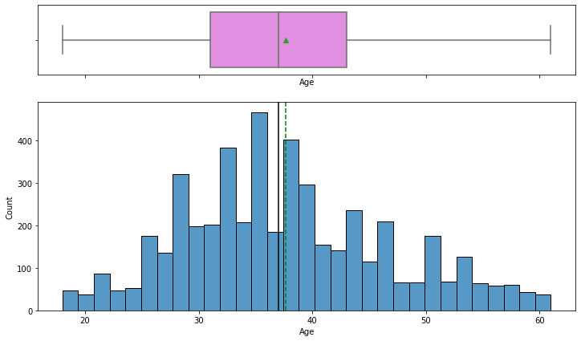

```python
histogram_boxplot(df,'Age')
```

# • Age is normally distributed with a hint of right skewness.

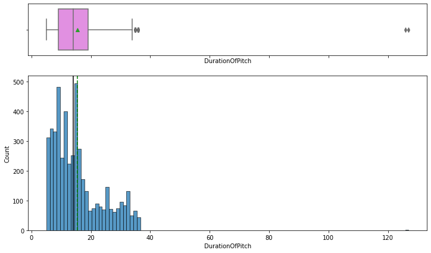

```python
histogram_boxplot(df,'DurationOfPitch')
```

# • Duration of pitch is skewed to the right with a few outliers.

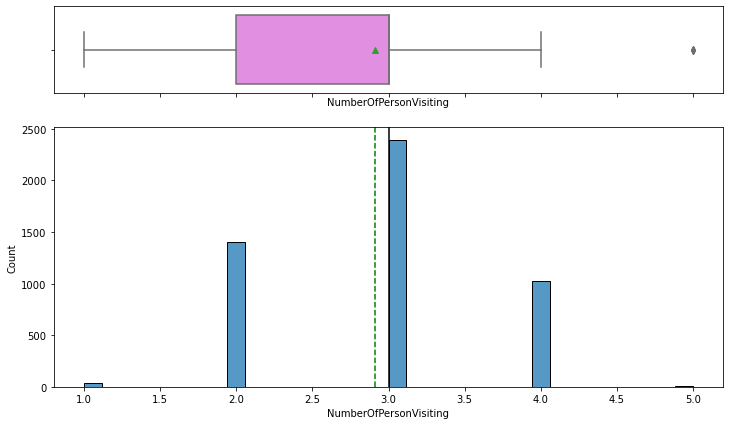

```python
histogram_boxplot(df,'NumberOfPersonVisiting')
```

# • Number of visitors is normally distributed with few outliers.

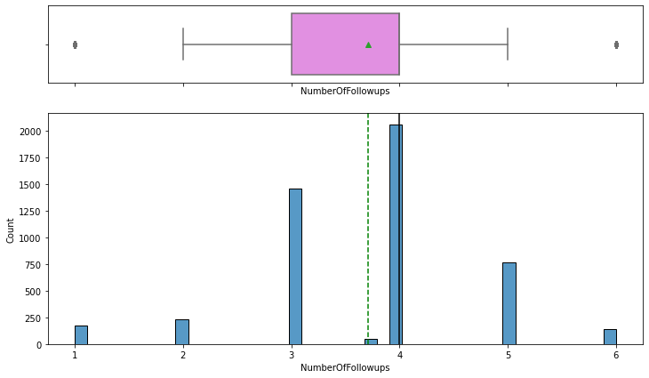

```python
histogram_boxplot(df,'NumberOfFollowups')
```

# • Number of followups is slightly skewed left, with some outliers.

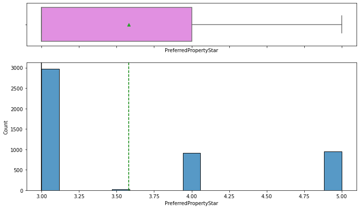

```python
histogram_boxplot(df,'PreferredPropertyStar')
```

# • Most customers prefer a facility rating around 3. This may be related to costs and quality balance for the customer.

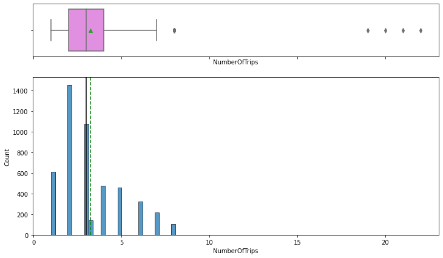

```python
histogram_boxplot(df,'NumberOfTrips')
```

# • Number of Trips is skewed right, with some outliers. Most customers have taken about two trips.

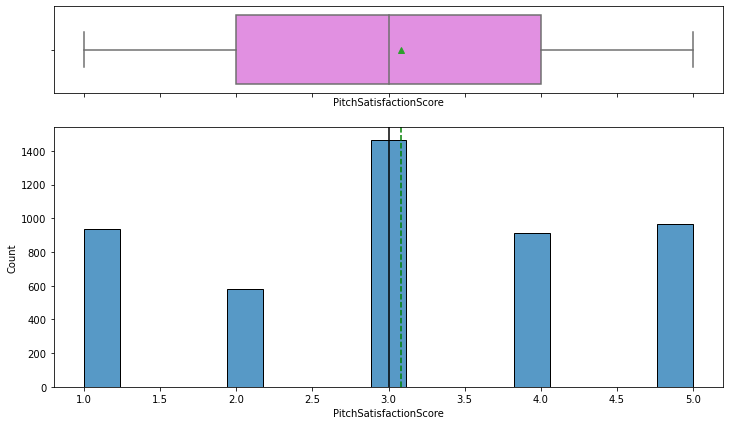

```python
histogram_boxplot(df,'PitchSatisfactionScore')
```

# • Pitch satisfaction score has a normal distribution, with an average close to 3 out of 5. This may indicate a low impact on the customers decision to buy a trip.

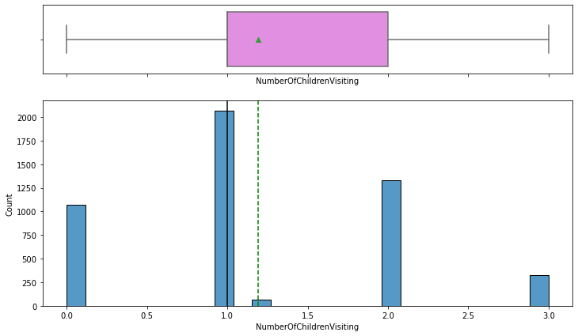

```python
histogram_boxplot(df,'NumberOfChildrenVisiting')
```

# • Typically, families with only one child purchase a package. This could indicate that the trips are not family friendly, or more guests with newly started families visit. Larger families that purchase a trip have no more than three children.

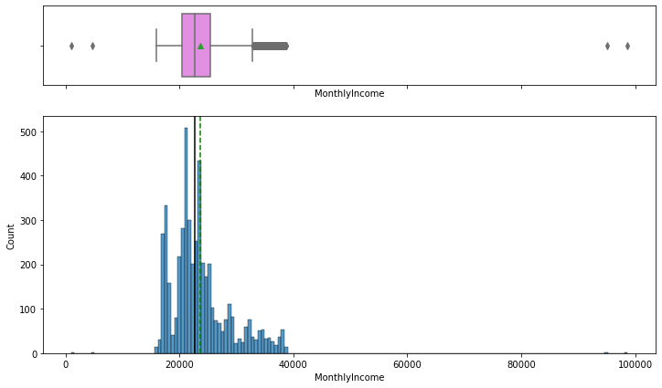

```python
histogram_boxplot(df,'MonthlyIncome')
```

# • Monthly Income is skewed right, with outliers on either end of the spectrum. The average is about $23,000/month.

# Outliers

We will not treat outliers as they are values that are likely to occur in this type of business.

```python
# function to create labeled barplots


def labeled_barplot(data, feature, perc=False, n=None):
    """
    Barplot with percentage at the top

    data: dataframe
    feature: dataframe column
    perc: whether to display percentages instead of count (default is False)
    n: displays the top n category levels (default is None, i.e., display all levels)
    """

    total = len(data[feature])  # length of the column
    count = data[feature].nunique()
    if n is None:
        plt.figure(figsize=(count + 1, 5))
    else:
        plt.figure(figsize=(n + 1, 5))

    plt.xticks(rotation=90, fontsize=15)
    ax = sns.countplot(
        data=data,
        x=feature,
        palette="Paired",
        order=data[feature].value_counts().index[:n].sort_values(),
    )

    for p in ax.patches:
        if perc == True:
            label = "{:.1f}%".format(
                100 * p.get_height() / total
            )  # percentage of each class of the category
        else:
            label = p.get_height()  # count of each level of the category

        x = p.get_x() + p.get_width() / 2  # width of the plot
        y = p.get_height()  # height of the plot

        ax.annotate(
            label,
            (x, y),
            ha="center",
            va="center",
            size=12,
            xytext=(0, 5),
            textcoords="offset points",
        )  # annotate the percentage

    plt.show()  # show the plot
```

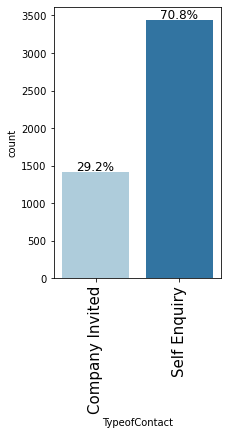

```python
#Visualizing how customers were contacted.
labeled_barplot(df, "TypeofContact", perc=True)
```

• Low company contact may have contributed to missed sales.

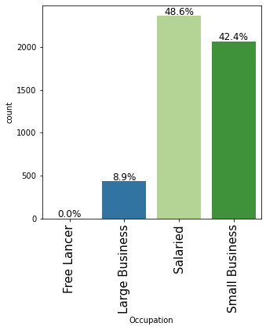

```python
labeled_barplot(df,'Occupation', perc=True)
```

• Free Lancers and Large Business owners do not seem to be generating sales. This is something the marketing team should look at.

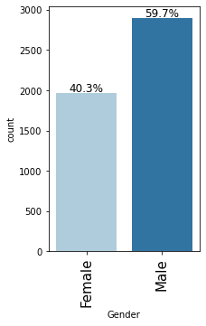

```python
labeled_barplot(df,'Gender', perc=True)
```

• We see here that men purchase at a higher rate then women. This may be linked to the small number of children that are on purchased trips; women typically are in charge of childcare and often work more than relax when on vacations; perhaps the company and come up with something to alleviate.

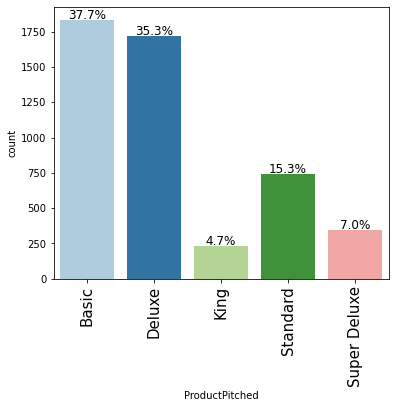

```python
labeled_barplot(df,'ProductPitched', perc=True)
```

• Basic and Deluxe are the two packages that are pitched the most. Sales representatives may need training on how to pitch the higher tier packages and be successful doing so.

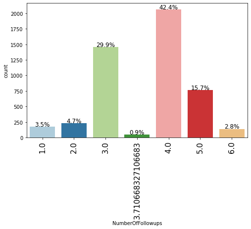

```python
labeled_barplot(df,'NumberOfFollowups', perc=True)
```

• Most customers are followed up with four times, followed by three times.

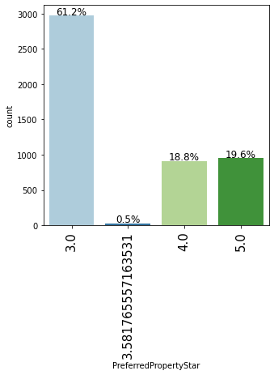

```python
labeled_barplot(df,'PreferredPropertyStar', perc=True)
```

• Compared to all properties; those with a rating of three are a customer favorite. This may be cost and value related.

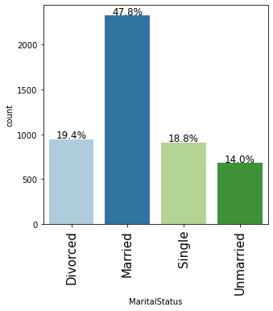

```python
labeled_barplot(df,'MaritalStatus', perc=True)
```

• Married couples purchase the most with not much difference between Divorced, Single, and Unmarried. Perhaps programs and activities where single people can mingle would increase sales in lower performing areas.

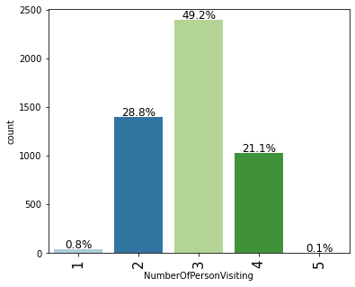

```python
labeled_barplot(df,'NumberOfPersonVisiting', perc=True)
```

• Above we see most visitors come in parties of three.

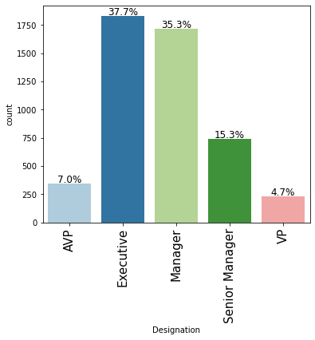

```python
labeled_barplot(df,'Designation', perc=True)
```

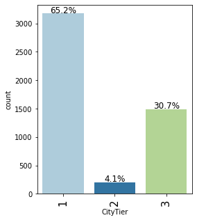

```python
labeled_barplot(df,'CityTier', perc=True)
```

• Surprisingly people from the lowest City Tier make the most purchases. These individuals may need an escape to a relaxing environment; under development, crime, and etc. may play a factor. People from higher City Tiers may live in nicer areas and have nicer homes; and no need to vacation as much.

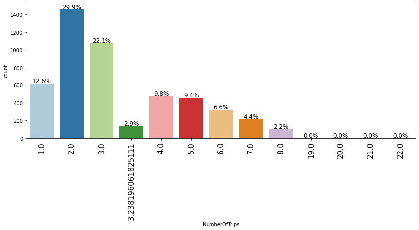

```python
labeled_barplot(df,'NumberOfTrips', perc=True)
```

• We see here that most patrons have made two purchases for trips.

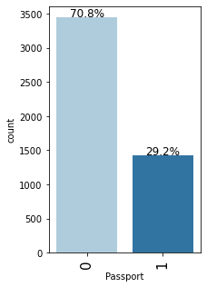

```python
labeled_barplot(df,'Passport', perc=True)
```

• Customers without passports made more purchases than passport holders.

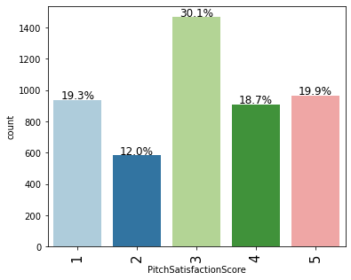

```python
labeled_barplot(df,'PitchSatisfactionScore', perc=True)
```

• Most people that were neither satisfied nor dissatisfied with the pitch made the most purchases. This may indicate the pitch had no effect on whether a purchase was made. The marketing team may need to scrap the current pitch and create new material.

# Bivariate Analysis

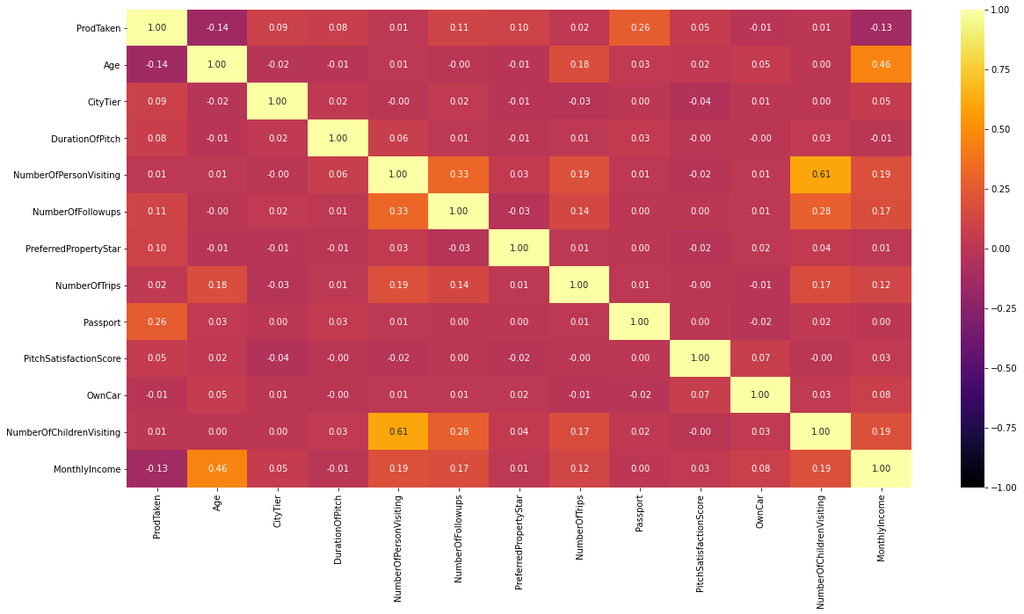

```python
plt.figure(figsize=(20,10))
sns.heatmap(df.corr(),annot=True,vmin=-1,vmax=1,fmt='.2f',cmap="inferno")
plt.show()
```

• The highest correlation we see here is between ‘NumberOfPersonVisiting’ and ‘NumberofChildrenVisiting’; there is no surprise here.

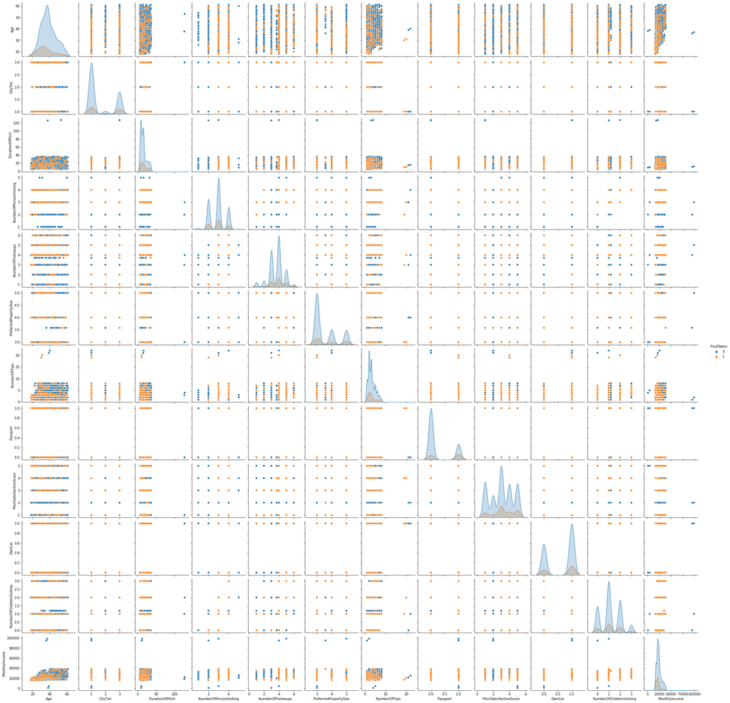

```python
sns.pairplot(df,hue='ProdTaken')
plt.show()
```

• Distributions in variables for ‘Prodtaken’ have varying distributions; we will take a deeper look.

```python
### function to plot distributions wrt target


def distribution_plot_wrt_target(data, predictor, target):

    fig, axs = plt.subplots(2, 2, figsize=(12, 10))

    target_uniq = data[target].unique()

    axs[0, 0].set_title("Distribution of target for target=" + str(target_uniq[0]))
    sns.histplot(
        data=data[data[target] == target_uniq[0]],
        x=predictor,
        kde=True,
        ax=axs[0, 0],
        color="teal",
        stat="density",
    )

    axs[0, 1].set_title("Distribution of target for target=" + str(target_uniq[1]))
    sns.histplot(
        data=data[data[target] == target_uniq[1]],
        x=predictor,
        kde=True,
        ax=axs[0, 1],
        color="orange",
        stat="density",
    )

    axs[1, 0].set_title("Boxplot w.r.t target")
    sns.boxplot(data=data, x=target, y=predictor, ax=axs[1, 0], palette="gist_rainbow")

    axs[1, 1].set_title("Boxplot (without outliers) w.r.t target")
    sns.boxplot(
        data=data,
        x=target,
        y=predictor,
        ax=axs[1, 1],
        showfliers=False,
        palette="gist_rainbow",
    )

    plt.tight_layout()
    plt.show()
```

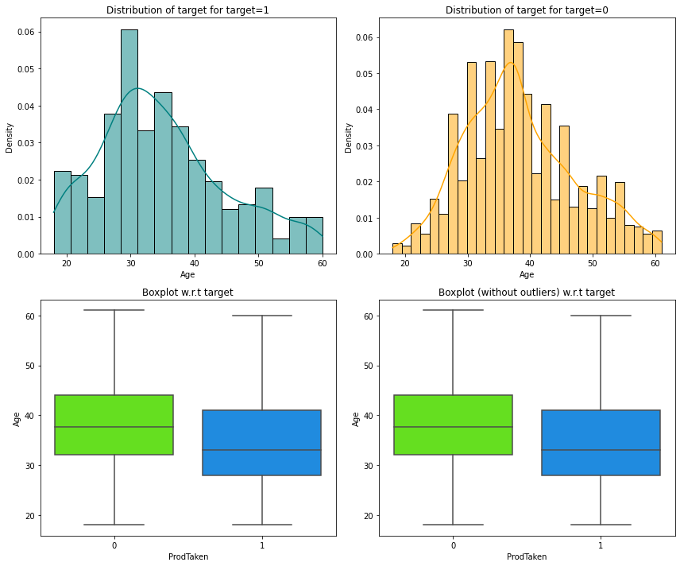

```python
distribution_plot_wrt_target(df, "Age", "ProdTaken")
```

• Most people that made a purchase were around 30 years old, while people that did not make a purchase were closer to 40.